# Lab 12

Drew Hoffman, Tanner Ball, Burke Parent, David Washburn, Brandon Nelsen

11/12/2019

```r
library(tidyverse)
library(gapminder)
UgandaUSA <- filter(gapminder_unfiltered, country == "Uganda" | country == "United States", year >= 1977)
lifeExpcombined <- c(UgandaUSA$lifeExp)
```

# Gapminder Questions

Your data science team must come up with two specific questions of interest about the gapminder data set (from ‘gapminder’ library).

*Question one:*

Has life expectancy in Uganda changed (percentage-wise) more than the United States since 1977?

*Question Two:*

IS GDP per capita correlated with population?

*Briefly describe the gapminder dataset.*

The gapminder dataset was created to give access of easy to digest data about various socioeconomic statistics in each country, it is made to educate others and help bring to light some of those socioeconomic issues around the globe.

*Explain why your questions are important. One of the questions should be answered with the two-sample mean permutation test, and the other with the correlation permutation test.*

Our first question is important because we want to see if the development of a random country we picked in Africa is happening at an accelerated pace due possibly to the rise of new technology or the advancement of aid to third world countries. This can help us understand the pace at which African and third world countries in general can become first-world, if possible.

Our second question is important because it can help us look at future trends in population growth based on GDP, if a country with high GDP has more population growth, it can help a country better prepare for the influx in population or if a country is growing rapidly it can help a country prepare for a growth in GDP.

*Finish the function skeletons to implement the two-sample permuation test and the correlation permutation test. Run a two-sample mean permutation test. Run a correlation permutation test.*

Two-Sample Permutation Function:

```r
perm_mean <- function(perms = 1000, all_values, n_A)
{
  ## Variables ##
  # perms: The number of permutations
  # all_values (num): all data values
  # n_A (int): Size of group A
  ###############

  # Step 1:
  # Create vector of zeroes of length "perms" to store
  # permuted mean differnces
  perm_mean_diffs <- numeric(perms)

  # Loop throught number of permutations
  for (i in c(1:perms))
  {
    # Step 2:
    # Randomly separate vector "values" into disjoint
    # groups of size "nA" and "nB" respectively
    rand_vector <- sample(all_values)
    group_a <- rand_vector[1:n_A]
    group_b <- rand_vector[(n_A+1):length(all_values)]

    # Step 3:
    # Compute the sample means for the two groups from
    # step 2
    mean_a <- mean(group_a)
    mean_b <- mean(group_b)

    # Step 4:
    # Compute the difference in sample means, store the
    # value in the vector from step 1
    diff_means <- mean_a - mean_b
    perm_mean_diffs[i] <- diff_means

  }

  # Step 5:
  # Return the permuted mean differences vector
  return(perm_mean_diffs)

}
```

Correlation Permutation Function:

```r
perm_cor <- function(perms = 1000, x, y)
{
  ## Variables ##
  # perms: The number of permutations
  # x: Vector of Variable 1 - for computing correlation
  # y: Vector of Variable 2 - for computing correlation
  ###############

  # Step 1:
  # Create vector of zeroes of length "perms" to store
  # permuted mean differnces
  cor_coeffs <- numeric(perms)

  # Loop throught number of permutations
  for (i in c(1:perms))
  {
    # Step 2:
    # Randomly mix up the values in the vector "y"
    mix_up <- sample(y)

    # Step 3:
    # Compute the correlation between x and the randomly mixed
    # up y-vector. Store this value in the vector from step 1.
    coefficient <- cor(x, mix_up)
    cor_coeffs[i] <- coefficient
  }

  # Step 4:
  # Return new updated vector, created in step 1
  return(cor_coeffs)
}
```

- Create visualizations of the statistical tests.

The Histogram below shows the distribution of the difference of life expectencies between Uganda and The United States after executing a two-sample permutation function. This was done to see if the labels on the data were significant.

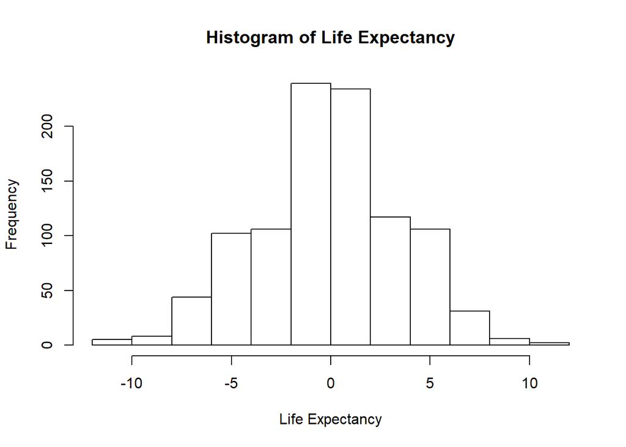

```r
perm_mean <- function(perms = 1000, all_values, n_A)
{

  perm_mean_diffs <- numeric(perms)

  for (i in c(1:perms))
  {

    rand_vector <- sample(all_values)
    group_a <- rand_vector[1:n_A]
    group_b <- rand_vector[(n_A+1):length(all_values)]


    mean_a <- mean(group_a)
    mean_b <- mean(group_b)

    diff_means <- mean_a - mean_b
    perm_mean_diffs[i] <- diff_means

  }


  return(perm_mean_diffs)

}

`Life Expectancy` <-
  perm_mean(1000, lifeExpcombined, length(lifeExpcombined) / 2)

hist(`Life Expectancy`)
```

```r
UGN <- filter(UgandaUSA, country == "Uganda")
USA <- filter(UgandaUSA, country == "United States")
UGNdiff <- 51.542 - 50.35 # 1.192
USAdiff <- 78.242 - 73.38 # 4.86
USdiff_UGNdiff <- USAdiff - UGNdiff # 3.67
```

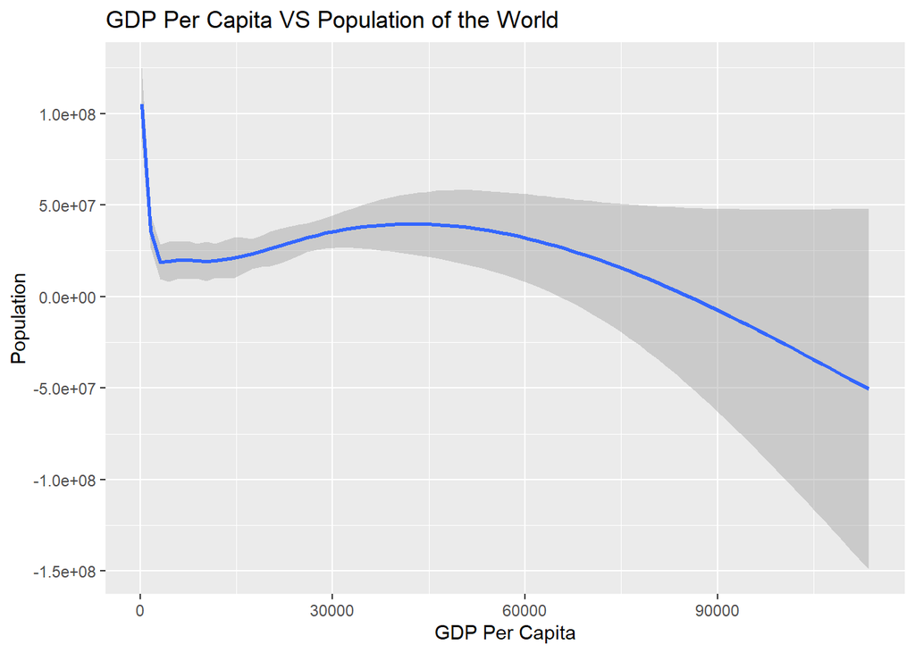

```r
#Create a smooth plot comparing GDP per capita and Population

ggplot(gapminder_unfiltered, aes(gdpPercap, pop)) +
  geom_smooth() +
  xlab("GDP Per Capita") +
  ylab("Population") +
  ggtitle("GDP Per Capita VS Population of the World")
```

```r
#Check Correlation

cor(gapminder_unfiltered$pop, gapminder_unfiltered$gdpPercap) # -.046
```

```
## [1] -0.04595259
```

- Make data-based conclusions about the results. Do you believe there are differences among the groups you are comparing?

The Histogram tells us that values that fall within the majority of the data are not statistically significant, so if a value falls within that range we can not draw a conclusion.

The difference in life expectency for Uganda and The United States from 1977 to 2007 are respectively 1.192 years and 4.86 years. The difference between those two values is 3.67 years. Hence, we fail to reject the null hypothesis since all of those values fall within the previously specified range. Therefore we can not make any conclusions.

When comparing GDP per Capita and population, we can conclude that there is no linear relationship when all countries are taken into account.

- Generate percentiles, summary statistics (max, min), and probabilites (p-values) to justify your conclusions.

```r
#min of Histogram

min_life_expectancy <- min(`Life Expectancy`)
min_life_expectancy #-11.028
```

```
## [1] -11.12589
```

```r
#max of Histogram

max_life_expectancy <- max(`Life Expectancy`)
max_life_expectancy #10.778
```

```
## [1] 10.11956
```

```r
#generate percentiles for our values

                               #1.192, 3.67, 4.86
quantile(`Life Expectancy`, c(.59945, .8223, .9193))
```

```
##  59.945%   82.23%   91.93%
## 1.032501 3.505433 4.732650
```

```r
#set a 95% confidence interval and find the 2.5 percentile and 97.5 percentile

quantile(`Life Expectancy`,c(.025, .975)) # -7.267 and 7.44 respectively
```

```
##      2.5%     97.5%
## -7.537697  7.124844
```

- Summarize each individual’s contribution to the lab.

Tanner: Formatting and Visualization 1

Drew: Code, Descriptions

Brandon: Questions and the second function

David: Visualization 2, Conclusion, Justification